# Project 3 - Data Analysis using R by Arturo Battinelli

### Plot Three

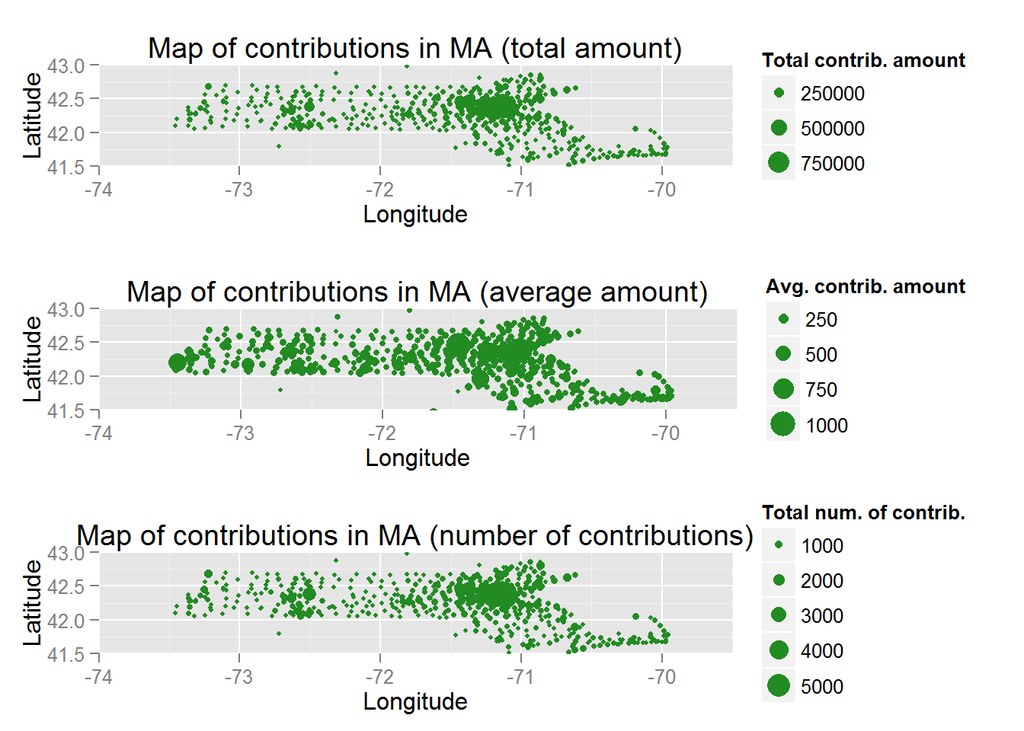

### Description Three

Here are three maps of the State of Massachusetts, where each point represents the contributions for that location. In the upper plot the point size corresponds to the total amount of contributions, the second plot the size stands for the average amount and in the third plot size represents the total number of contributions. As we can see, while most of contributions came from the closer Boston area (both in terms of amount and number), instead the average amount has high values in other places of the State. This tells us that yes, the capital city is where most of the fundraising happens, but still some very big isolated contributors can be found in the rest of the State.

# Reflection

The dynamics of the fundraising campaigns appear to be influenced by several factors. Here are the main insights that we could successfully get from the MA 2012 dataset.

- The time to the elections has a clear impact. The number of contributions raises very quickly as the elections get close. At the same time, those increasing (in number) contributions become smaller as the time passes. As we could see by splitting data with respect to amount buckets, this is mostly due to small contributions (below 500$) which grow heavily (and much more than any other buckets) in the last 100 days before the elections. This suggests us to think that “people’s” contributions becomes strong and effective at last, when the fight gets tougher. On the other hand, “big” contributors (such as maybe companies) are more stable.
- Geography (and demographics) is another important element. Some parties are stronger than other within certain social classes and consequently more contributions may come from specific towns/locations where such classes are more concentrated. Might be interesting to compare this trend with the average income of each town, to see for example if every location contributes the same (compared to the average income), or if there are some towns where people is actually contributing more, not only in absolute terms, but also in comparison to the average income. Such results could reveal interesting insights about the people’s engagement with politics.
- Political and/or social events have impacts on the contributions and may cause parties to receive alternatively more funds within certain periods. Analyzing this aspect more in depth could lead to even predictive results, which might eventually lead to be able to foresee the impact (in terms of contributions) of possible actions that the candidate or the party may want to take during the political campaign.

Let’s close with some issues or open points related to this analysis.

- The way I have calculated the distances between zipcodes is a pure geometrical result and do not reflect the actual distance along the State’s roadways. This could make some of the calculations based on distance not completely accurate. In order to improve this side of the analysis, one may use API calls to some providers on the Web which offer this kind of services. A similar approach could be used to enrich the dataset with relevant information related to each town’s citizenship (as mentioned above).
- Information in this dataset is highly “clustered”, as for example Democrats and Republicans represent the great majority of the contributions. Having a more “balanced” dataset could have resulted in a more varied analysis.
- Information about contributors is not very rich. The availability of more data elements such as age or employment could have allowed further analyses. We do have a column showing the contributor’s occupation, but apparently this comes from a free-text field and as such it contains unstructured data which would require some heavy clean-up and categorization/grouping before being ready for use.